title: “3-4-1 QA” author: “Michael Nairn” date: “21/11/2022” output: html_document

## 3-4-1 update summary

3-4-1 is an indicator that uses a NOMIS API link to provide data. Unless the format of NOMIS API downloads changes, the update_3-4-1 script should not need changing. However, always check before running the update script.

This file runs some basic checks and gives information about the update.

Before putting the csv in the indicator file please check if the most recent figures are provisional. Check this in the source data. If they are, in the indicator csv file change the observation status to ‘Provisional’.

## Plots

Please check the plots below for any differences between the live and new data. Live data will appear over the top of new data, so if you don’t see points for the new data on dates where there is also live data this is a good thing.

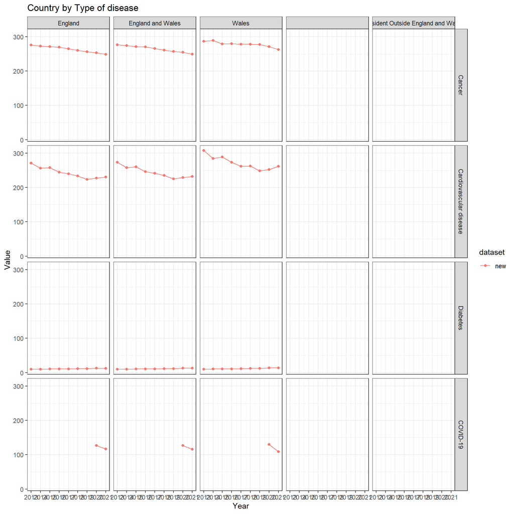

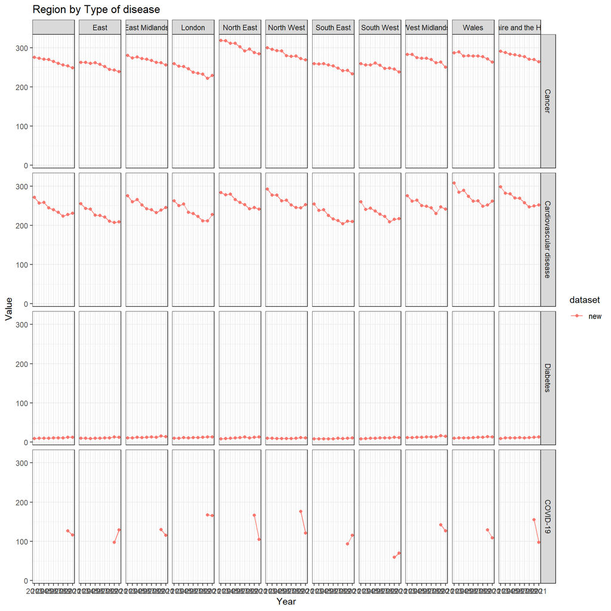

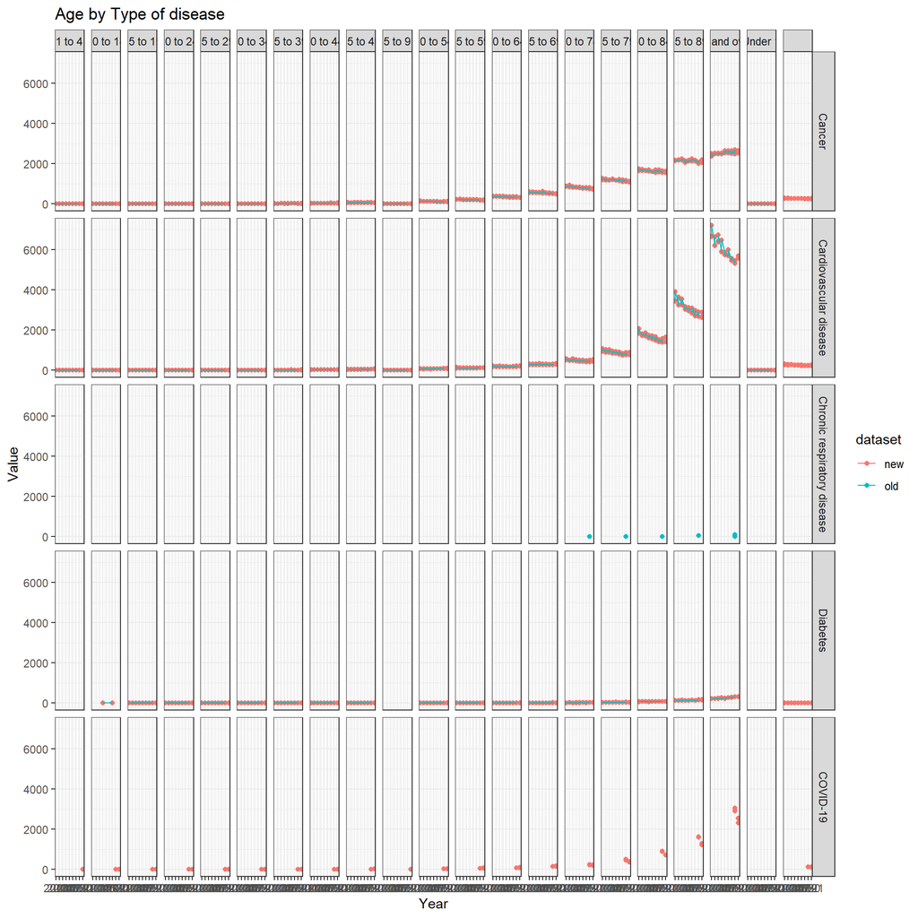

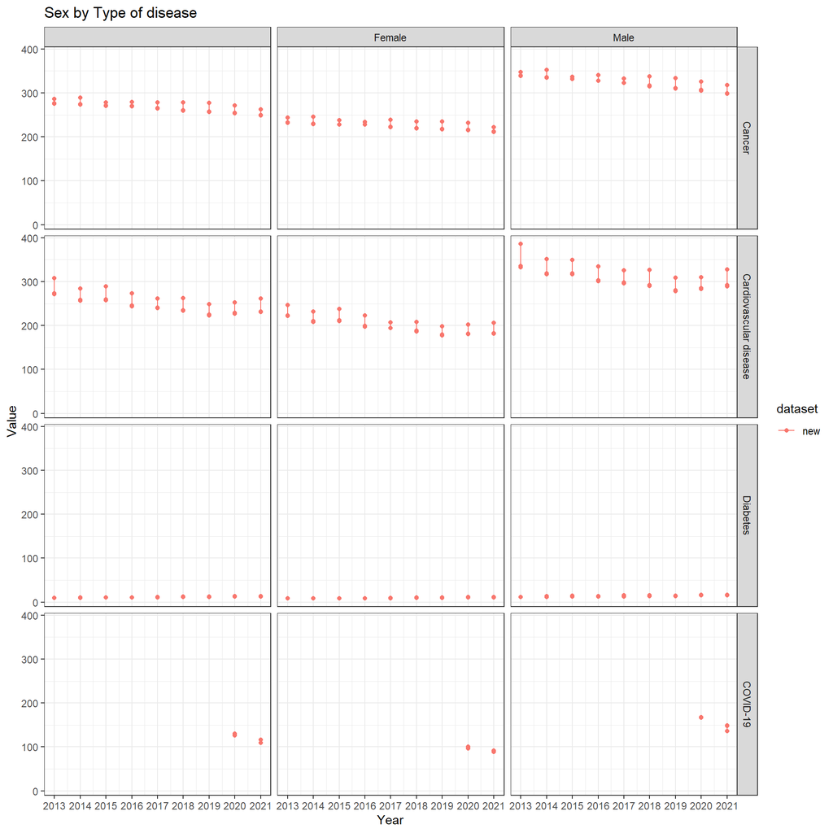

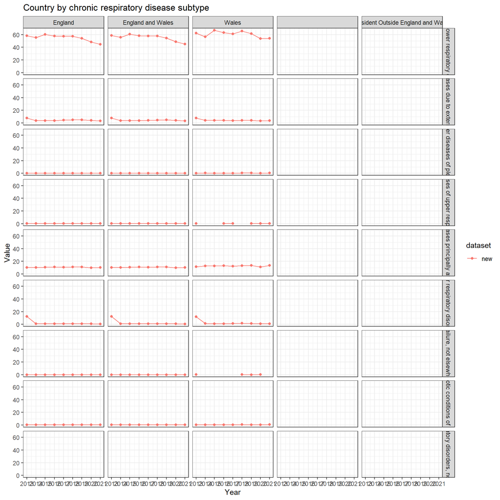

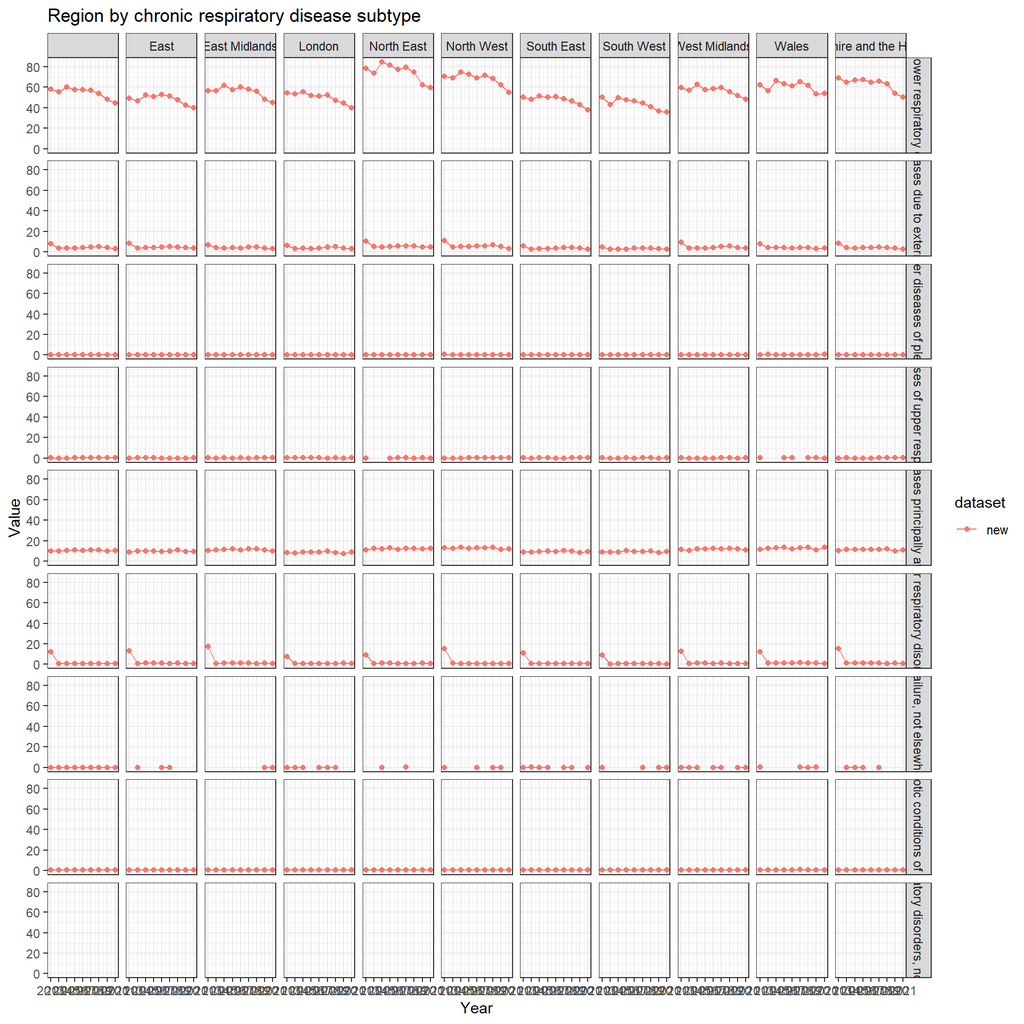

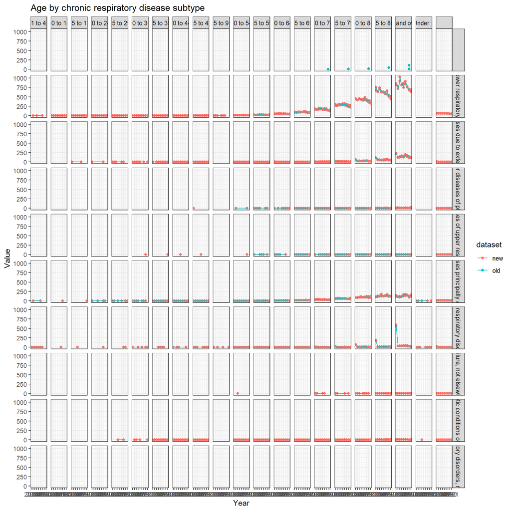

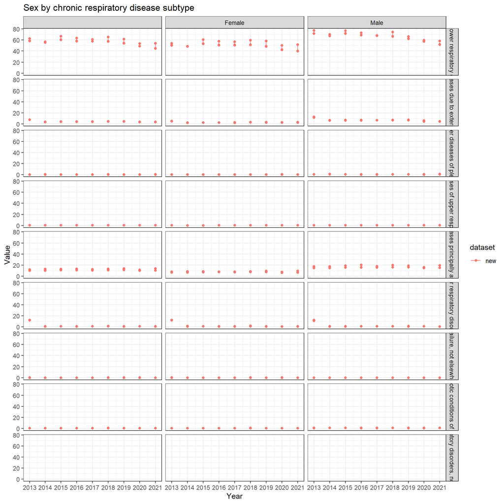

If there are differences, visible in the table below and plots, please investigate these. It is possible the data source has update its back time series, so the difference could be genuine.

The table below shows all instances where the old value does not match the new value. It is sorted so the largest absolute differences appear first, but can be sorted in other ways using the arrows at the top.

| Year | Country | Region | Age | Sex | Type of disease | Chronic respiratory disease subtype | old | new | difference |
| --- | --- | --- | --- | --- | --- | --- | --- | --- | --- |
| 2020 | England | North West | 90 and over | Male | Chronic respiratory disease | Other respiratory disorders | 17.52 | 24.56 | 7.04 |
| 2020 | England | North West | 85 to 89 | Male | Chronic respiratory disease | Suppurative and necrotic conditions of lower respiratory tract | 5.39 | 6.84 | 1.45 |
| 2020 | England | North West | 85 to 89 | Male | Chronic respiratory disease | Other respiratory disorders | 5.39 | 6.84 | 1.45 |
| 2020 | England | North West | 80 to 84 | Male | Chronic respiratory disease | Other respiratory disorders | 4.7 | 3.58 | -1.12 |

**R version 3.6.3 (2020-02-29)**

**Platform:** x86_64-w64-mingw32/x64 (64-bit)

**locale:** *LC_COLLATE=English_United Kingdom.1252*, *LC_CTYPE=English_United Kingdom.1252*, *LC_MONETARY=English_United Kingdom.1252*, *LC_NUMERIC=C* and *LC_TIME=English_United Kingdom.1252*

**attached base packages:** *tools*, *stats*, *graphics*, *grDevices*, *utils*, *datasets*, *methods* and *base*

**other attached packages:** *pander(v.0.6.3)*, *DT(v.0.25)*, *kableExtra(v.1.3.4)*, *ggplot2(v.3.3.3)*, *tibble(v.3.1.1)*, *stringr(v.1.4.0)*, *dplyr(v.1.0.6)*, *tidyr(v.1.1.3)* and *SDGupdater(v.0.0.0.9000)*

**loaded via a namespace (and not attached):** *tinytex(v.0.31)*, *tidyselect(v.1.1.1)*, *xfun(v.0.22)*, *bslib(v.0.2.4)*, *purrr(v.0.3.4)*, *colorspace(v.2.0-1)*, *vctrs(v.0.3.8)*, *generics(v.0.1.2)*, *htmltools(v.0.5.1.1)*, *viridisLite(v.0.4.0)*, *yaml(v.2.2.1)*, *utf8(v.1.2.1)*, *rlang(v.0.4.11)*, *later(v.1.2.0)*, *jquerylib(v.0.1.4)*, *pillar(v.1.6.0)*, *glue(v.1.4.2)*, *withr(v.2.5.0)*, *DBI(v.1.1.2)*, *lifecycle(v.1.0.0)*, *munsell(v.0.5.0)*, *gtable(v.0.3.0)*, *rvest(v.1.0.0)*, *zip(v.2.1.1)*, *htmlwidgets(v.1.5.4)*, *evaluate(v.0.15)*, *labeling(v.0.4.2)*, *knitr(v.1.33)*, *fastmap(v.1.1.0)*, *httpuv(v.1.6.1)*, *crosstalk(v.1.2.0)*, *fansi(v.0.4.2)*, *highr(v.0.9)*, *Rcpp(v.1.0.6)*, *xtable(v.1.8-4)*, *promises(v.1.2.0.1)*, *scales(v.1.1.1)*, *webshot(v.0.5.2)*, *jsonlite(v.1.7.2)*, *mime(v.0.10)*, *farver(v.2.1.0)*, *systemfonts(v.1.0.2)*, *digest(v.0.6.27)*, *stringi(v.1.6.1)*, *openxlsx(v.4.2.3)*, *shiny(v.1.6.0)*, *grid(v.3.6.3)*, *cli(v.2.5.0)*, *magrittr(v.2.0.1)*, *sass(v.0.4.0)*, *crayon(v.1.5.1)*, *pkgconfig(v.2.0.3)*, *ellipsis(v.0.3.2)*, *xml2(v.1.3.2)*, *assertthat(v.0.2.1)*, *rmarkdown(v.2.8)*, *svglite(v.2.0.0)*, *httr(v.1.4.2)*, *rstudioapi(v.0.13)*, *R6(v.2.5.1)* and *compiler(v.3.6.3)*